# A Rasch analysis workflow with easyRasch2

## Overview

This vignette walks through the steps of a Rasch analysis using data from the nine-item Patient Health Questionnaire (PHQ-9; Kroenke et al. (2001)). The example follows the four psychometric criteria proposed by Christensen et al. (2021) for the validation of patient-reported outcome measures (PROMs):

1. **Unidimensionality** — the items measure a single latent construct.
2. **Local independence** — after conditioning on the latent trait, item responses are independent of each other.
3. **Ordered response category thresholds** (monotonicity) — moving up the latent trait increases the probability of higher categories.
4. **Invariance / no DIF** — item parameters are the same across relevant external groups (e.g. gender).

We then move on to complementary descriptors that are commonly reported alongside the four criteria above:

- Targeting — how well person and item locations overlap on the latent continuum.
- Reliability — how precisely the scale separates respondents, overall and at each point on the scale.
- Person fit — unexpected response patterns.
- Item and person parameters — estimates for reuse in scoring.

For a more extensive treatment of Rasch analysis in R, see https://pgmj.github.io/raschrvignette/RaschRvign.html. For a Bayesian sibling package, see https://pgmj.github.io/easyRaschBayes/.

> **NOTE:** all simulation-based functions use a low number of iterations to make this vignette render faster. You should use more iterations for actual analysis work. 400 is the calibrated floor for the multiplicity-corrected *p*-values and is the package default, while 1000 to 2000 is advisable for a final analysis, since decisions about items near the decision boundary can change with the seed: at 400 iterations, two analyses with different seeds disagree about at least one item roughly 10 percent of the time (Johansson 2026). An earlier recommendation, that fewer iterations could improve detection for conditional infit at small samples, is withdrawn: that advantage came from an expected range that had not converged, and it was paid for with an inflated family-wise error rate. A false discovery rate correction (`correction = "fdr_bh"` or `"fdr_by"`) needs far more iterations than the default family-wise one, because a bootstrap *p*-value can be no smaller than $1/(B+1)$.

To get faster simulations, please make use of `options(mc.cores = 4)`, where `4` should be replaced with the number of high performance CPU cores your computer has available. This setting is automatically applied by all functions that can use parallel processing.

## Data

The bundled `phq9` dataset is a 600-respondent random subsample of the PHQ-9 module from the U.S. National Health and Nutrition Examination Survey (NHANES, September 2024 release) with complete responses on all nine items. NHANES microdata are released to the public domain by the U.S. federal government.

```r
library(easyRasch2)
data(phq9)
items <- phq9[, 1:9]   # 9 item columns, scored 0..3

# add item information
item_desc <- c(
  "Little interest or pleasure in doing things",
  "Feeling down, depressed, or hopeless",
  "Trouble falling or staying asleep, or sleeping too much",
  "Feeling tired or having little energy",
  "Poor appetite or overeating",
  "Feeling bad about yourself - or that you are a failure or have let yourself or your family down",
  "Trouble concentrating on things, such as reading the newspaper or watching television",
  "Moving or speaking so slowly that other people could have noticed",
  "Thoughts that you would be better off dead or of hurting yourself in some way"
)

item_resp <- c("Not at all","Several days","More than \nhalf the days","Nearly every day")
```

```r
str(items)
```

```
#> 'data.frame':    600 obs. of  9 variables:
#>  $ q1: int  3 0 1 2 3 3 1 3 2 1 ...
#>  $ q2: int  3 0 2 3 3 3 1 3 2 0 ...
#>  $ q3: int  3 1 3 0 3 1 0 3 2 0 ...
#>  $ q4: int  3 1 3 2 3 3 1 3 2 0 ...
#>  $ q5: int  3 0 3 2 3 2 0 1 2 0 ...
#>  $ q6: int  3 2 3 2 3 2 2 3 3 0 ...
#>  $ q7: int  3 3 3 2 3 2 2 3 3 0 ...
#>  $ q8: int  1 0 2 0 3 3 0 0 1 0 ...
#>  $ q9: int  3 0 0 2 3 1 2 0 0 0 ...
```

```r
summary(rowSums(items))
```

```
#>    Min. 1st Qu.  Median    Mean 3rd Qu.    Max.
#>    0.00   10.00   16.00   15.41   21.00   27.00
```

```r
table(phq9$gender, useNA = "ifany")
```

```
#>
#> Female   Male   <NA>
#>    426    143     31
```

```r
summary(phq9$age)
```

```
#>    Min. 1st Qu.  Median    Mean 3rd Qu.    Max.
#>   15.00   26.00   33.00   36.06   44.00   85.00
```

### Descriptive plots

Before fitting any model it is worth eyeballing the response distributions:

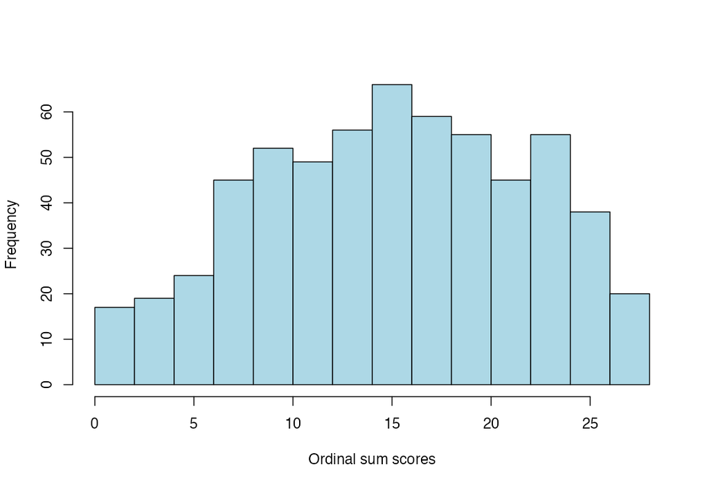

**Figure 1.** *Histogram of ordinal sum scores*

```r
hist(rowSums(items), col = "lightblue", main = "", xlab = "Ordinal sum scores")
```

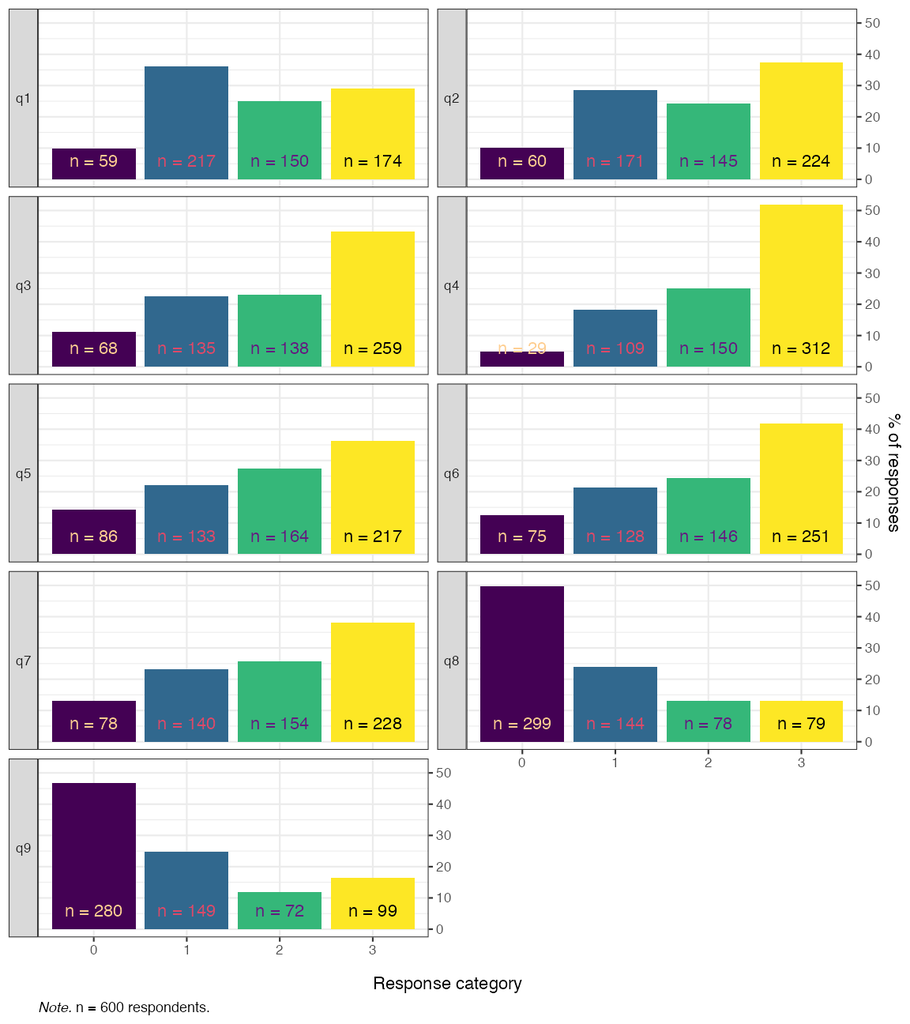

**Figure 2.** *Faceted bar chart of response distributions*

```r
RMplotBar(items, ncol = 2)
```

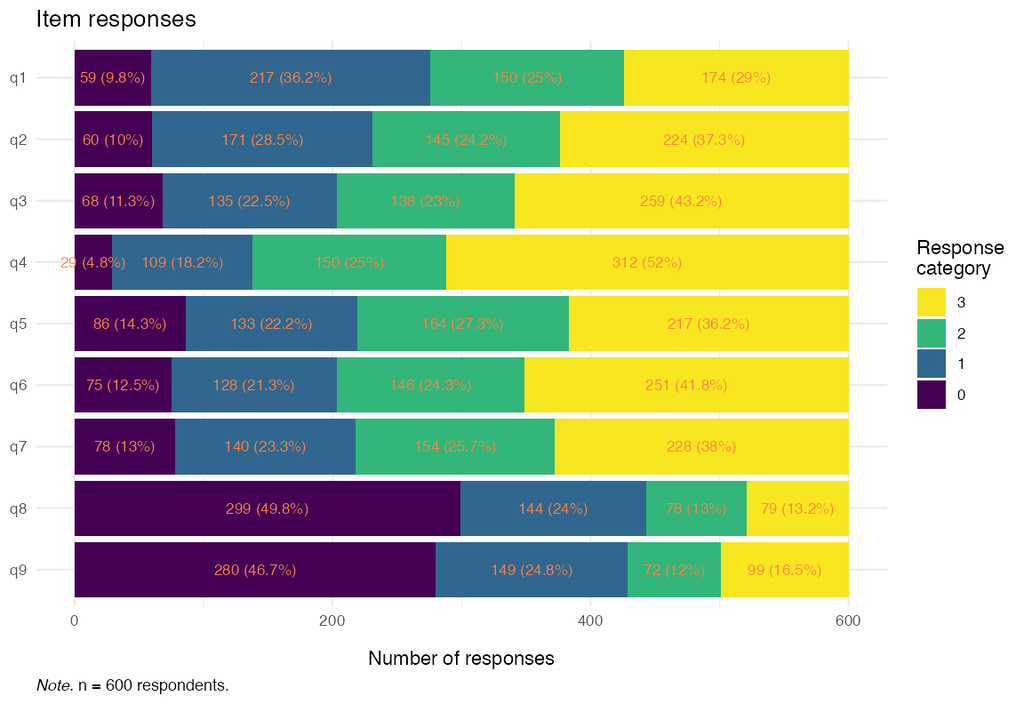

**Figure 3.** *Stacked-bar response distribution*

```r
RMplotStackedbar(items, show_percent = TRUE)
```

## 1. Unidimensionality

`easyRasch2` provides several complementary unidimensionality diagnostics that can be combined for a robust conclusion:

- item-level conditional infit MSQ statistics (Müller 2020)
- item-level item-restscore associations with Goodman-Kruskal’s $\gamma$ (gamma) (Kreiner 2011)
- confirmatory factor analysis (CFA) with WLSMV estimator for ordinal data
- principal components analysis (PCA) of the standardized residuals (Chou and Wang 2010)
- Martin-Löf test with Monte-Carlo *p*-values (Christensen and Kreiner 2007)

### Conditional infit MSQ

It is important to note that the `RMitemInfit()` function uses **conditional** infit, which is both robust to different sample sizes and makes ZSTD unnecessary (Müller 2020). Müller also questions the usefulness of outfit, and my simulation studies (Johansson 2025, 2026) reached the same conclusion. Thus, outfit is not reported.

Conditional item infit mean-square statistics flag items whose response patterns deviate from the Rasch expectation. With `RMitemInfitCutoff()`, per-item highest-density intervals serve as the reference instead of rule-of-thumb cutoffs (Johansson 2025). Passing the `RMitemInfitCutoff()` object to RMitemInfit() flags items on a multiplicity-corrected bootstrap *p*-value, with family-wise error rate (FWER; the default) or false discovery rate (FDR) correction, and the interval is reported alongside as a description of where a fitting item’s statistic is expected to fall (Johansson 2026).

> **NOTE:** `RMitemInfit()`, `RMitemRestscore()`, `RMlocdepQ3()`, `RMlocdepGamma()` and `RMdifGamma()` use the corrected *p*-value whenever the full cutoff object is supplied. `RMdimCFA()` and `RMdimResidualPCA()` take `p_value = TRUE` as an opt-in, and `RMitemInfitMI()` has no *p*-value path, so it always flags against the interval.

```r
infit_cut <- RMitemInfitCutoff(items, iterations = 100, parallel = FALSE,
                           seed = 3)
RMitemInfit(items, cutoff = infit_cut)
```

MSQ values based on conditional estimation. n = 600 respondents. Two-sided bootstrap p-values from 100 iterations, multiplicity correction: Westfall-Young step-down (FWER). Flagged on the corrected p-value at alpha = 0.05. p-values cannot be smaller than 1/(100+1) = 0.0099. This is below the calibrated floor of 400, where the correction is mildly liberal and the family-wise error rate sits above the nominal level (Johansson, 2026). Flagged: underfit (infit > 1) / overfit (infit < 1).

| Item | Infit MSQ | Infit low | Infit high | p | p (adj) | Flagged | Relative location |
| --- | --- | --- | --- | --- | --- | --- | --- |
| q1 | 0.946 | 0.911 | 1.097 | 0.2871 | 0.4554 |  | -0.56 |
| q2 | 0.778 | 0.924 | 1.107 | 0.0099 | 0.0099 | overfit | -0.76 |
| q3 | 1.234 | 0.897 | 1.107 | 0.0099 | 0.0198 | underfit | -0.83 |
| q4 | 0.835 | 0.893 | 1.098 | 0.0198 | 0.0396 | overfit | -1.48 |
| q5 | 1.069 | 0.917 | 1.102 | 0.1881 | 0.4356 |  | -0.58 |
| q6 | 0.895 | 0.926 | 1.097 | 0.0297 | 0.1386 |  | -0.76 |
| q7 | 0.986 | 0.919 | 1.101 | 0.7624 | 0.7624 |  | -0.66 |
| q8 | 1.260 | 0.880 | 1.119 | 0.0099 | 0.0099 | underfit | 0.97 |
| q9 | 1.315 | 0.842 | 1.107 | 0.0099 | 0.0099 | underfit | 0.79 |

You can also get a plot summarizing simulated and observed item infit, using `RMitemInfitPlot()`. Since conditional infit needs complete data, sibling functions that combine multiple imputation with conditional infit are useful when you have partial missingness: `RMitemInfitMI()` and `RMitemInfitCutoffMI()`.

Based on the table, items 3, 8, and 9 underfit the Rasch model, while items 2 and 4 are overfit. Item 2 is “Feeling down, depressed, or hopeless”, which is a very general item in terms of measuring depression, so this is expected.

A low item fit value, often referred to as an item being “overfit” to the Rasch model, indicates that responses may be too predictable. This is often the case for items that are very general/broad in scope in relation to the latent variable. You will often find overfitting items to also have local dependence (residual correlations) issues with other items. Overfit may be likened to having a much stronger factor loading than other items in a confirmatory factor analysis or a higher level of discrimination in an Item Response Theory model with two or more parameters.

A high item fit value, often referred to as being “underfit” to the Rasch model, can indicate several things. Often underfit is due to multidimensionality or a question that is difficult to interpret and thus has noisy response data. The latter could for instance be caused by a question that asks about two things at the same time, or is ambiguous for other reasons.

### Item-restscore

Item-restscore uses Goodman-Kruskal’s $\gamma$ (gamma) and shows the expected and observed correlation between an item and a score based on the rest of the items (Kreiner 2011). Similarly, but inverted, to item infit, a lower observed correlation value than expected indicates underfit, that the item may not belong to the dimension. A higher than expected observed value indicates an overfitting and possibly redundant item. Overfitting items will often also show issues with local dependency.

Without a cutoff, `RMitemRestscore()` uses an asymptotic *p*-value that is miscalibrated under the Rasch model: it flags too many items as overfit in small samples and too few as underfit at any sample size, which is in line with the asymptotic test detecting underfit less often than infit in an earlier simulation study (Johansson 2025). As for infit, passing the full `RMitemRestscoreCutoff()` object instead flags items on a multiplicity-corrected bootstrap *p*-value, and in simulation this test was more sensitive than infit to overfit and about equally sensitive to underfit.

```r
rs_cut <- RMitemRestscoreCutoff(items, iterations = 100, parallel = FALSE,
                                seed = 8)
RMitemRestscore(items, cutoff = rs_cut)
```

Item-restscore associations. n = 600 respondents. Two-sided parametric bootstrap p-values for the difference from 100 iterations, conditional DGP, multiplicity correction: Westfall-Young step-down (FWER). p-values cannot be smaller than 1/(100+1) = 0.0099. This is below the calibrated floor of 400, where the correction is mildly liberal (Johansson, 2026). Flagged (adj. p < 0.05): overfit = observed above expected (over-discrimination, often local dependence); underfit = below (under-discrimination, often multidimensionality/noise).

| Item | Observed | Expected | Difference | Diff low | Diff high | p | p (adj) | Flagged | Rel. location |
| --- | --- | --- | --- | --- | --- | --- | --- | --- | --- |
| q1 | 0.66 | 0.62 | 0.041 | -0.032 | 0.036 | 0.0396 | 0.1089 |  | -0.56 |
| q2 | 0.72 | 0.62 | 0.102 | -0.036 | 0.043 | 0.0099 | 0.0099 | overfit | -0.76 |
| q3 | 0.57 | 0.63 | -0.059 | -0.032 | 0.036 | 0.0099 | 0.0198 | underfit | -0.83 |
| q4 | 0.71 | 0.62 | 0.097 | -0.052 | 0.043 | 0.0099 | 0.0099 | overfit | -1.48 |
| q5 | 0.62 | 0.62 | -0.001 | -0.035 | 0.040 | 0.7921 | 0.7921 |  | -0.58 |
| q6 | 0.69 | 0.63 | 0.065 | -0.035 | 0.037 | 0.0099 | 0.0099 | overfit | -0.76 |
| q7 | 0.64 | 0.62 | 0.020 | -0.041 | 0.035 | 0.3069 | 0.4851 |  | -0.66 |
| q8 | 0.55 | 0.63 | -0.083 | -0.044 | 0.041 | 0.0099 | 0.0099 | underfit | 0.97 |
| q9 | 0.59 | 0.64 | -0.046 | -0.039 | 0.039 | 0.0198 | 0.0594 |  | 0.79 |

`RMitemRestscorePlot()` shows the simulated and observed differences in a plot.

Item-restscore found items 2, 4 and 6 to be overfit and items 3 and 8 to be underfit. It agrees with infit on items 2, 3, 4 and 8, adds item 6 as overfit, and leaves item 9, which infit found underfitting, just short of the threshold. The asymptotic test, `RMitemRestscore(items)` without a cutoff, misses the underfit of item 3. The two methods are best used together.

### CFA-based cutoffs for CFI / RMSEA and item loadings

`RMdimCFACutoff()` simulates data from a unidimensional PCM and fits a unidimensional ordinal CFA to each simulated dataset, building a parametric-bootstrap reference distribution for the model fit indices (SRMR, CFI, RMSEA) *and* for the per-item standardized factor loadings. It returns this simulation object; `RMdimCFA()` then fits the CFA to the observed data and tabulates the observed fit indices and loadings against the simulated reference. Observed values beyond the simulated cutoffs are implausible under a unidimensional data-generating process.

```r
cfa_cut <- RMdimCFACutoff(items, iterations = 100, parallel = FALSE,
                       seed = 2)
cfa_tbl <- RMdimCFA(items, cutoff = cfa_cut)
cfa_tbl$fit
```

Partial Credit Model posterior-predictive CFA fit-index check. Observed CFA fit (one-factor, lavaan WLSMV, ordered = TRUE) vs simulated null under PCM unidimensionality (100 iterations at n = 600 simulees). n = 600 respondents. Cutoffs one-sided at the 99th percentile; flagged when the observed value lies in the worst 1% of the null in the unfavourable direction.

| Index | Observed | Cutoff | Direction | Flagged |
| --- | --- | --- | --- | --- |
| CFI | 0.9623 | 0.9957 | < 1st pct | TRUE |
| RMSEA | 0.1217 | 0.0351 | > 99th pct | TRUE |
| SRMR | 0.0572 | 0.0257 | > 99th pct | TRUE |

```r
cfa_tbl$loadings
```

Standardized factor loadings (one-factor, lavaan WLSMV) vs the simulated expected range under PCM unidimensionality (100 iterations at n = 600 simulees). n = 600 respondents. Expected range is the two-sided central 99% interval of the simulated loadings; Flagged = below / above that range.

| Item | Observed | Expected low | Expected high | Flagged |
| --- | --- | --- | --- | --- |
| q1 | 0.790 | 0.682 | 0.786 | above |
| q2 | 0.876 | 0.689 | 0.809 | above |
| q3 | 0.693 | 0.707 | 0.814 | below |
| q4 | 0.823 | 0.664 | 0.824 |  |
| q5 | 0.737 | 0.699 | 0.812 |  |
| q6 | 0.797 | 0.702 | 0.821 |  |
| q7 | 0.753 | 0.704 | 0.805 |  |
| q8 | 0.670 | 0.692 | 0.816 | below |
| q9 | 0.718 | 0.709 | 0.816 |  |

`RMdimCFAPlot(cfa_cut, data = items)` returns a list of two figures: `$loadings` (observed loadings against their simulated expected ranges) and `$fit` (the simulated fit-index distributions with the observed values overlaid).

The table above agrees mostly with earlier findings. The overall model fit is clearly worse than expected under unidimensionality and item 2 is overfit (higher standardized factor loading than expected), with items 3 and 8 underfit (lower loadings). Additionally, the CFA flags item 1 as overfit. We should however take the simulation-based results with a grain of salt since we are using too few iterations to get reliable results.

### Residual PCA

After fitting the Rasch model, the residuals should contain no further systematic structure. The *largest eigenvalue* of the residual correlation matrix can be considered the headline diagnostic; a value clearly above the simulation-based cutoff suggests a secondary dimension. However, an eigenvalue below the cutoff does not by itself support unidimensionality.

```r
pca_cut <- RMdimResidualPCACutoff(items, iterations = 100, parallel = FALSE,
                       seed = 1)
RMdimResidualPCA(items, cutoff = pca_cut)
```

Partial Credit Model (9 items), n = 600 respondents. Total observed variance: 51.3% explained by measures, 48.7% unexplained. First-contrast cutoff = 1.217 based on 100 simulation iterations (99th percentile).

| Component | Eigenvalue | Proportion of variance | Flagged |
| --- | --- | --- | --- |
| PC1 | 1.520 | 0.200 | TRUE |
| PC2 | 1.341 | 0.176 | TRUE |
| PC3 | 1.113 | 0.146 | FALSE |
| PC4 | 0.909 | 0.119 | FALSE |
| PC5 | 0.853 | 0.112 | FALSE |

Also of interest is the plot of item standardized loadings on the first residual contrast and item locations. This figure can be helpful to identify clusters in data, perhaps related to local dependency and/or multidimensionality.

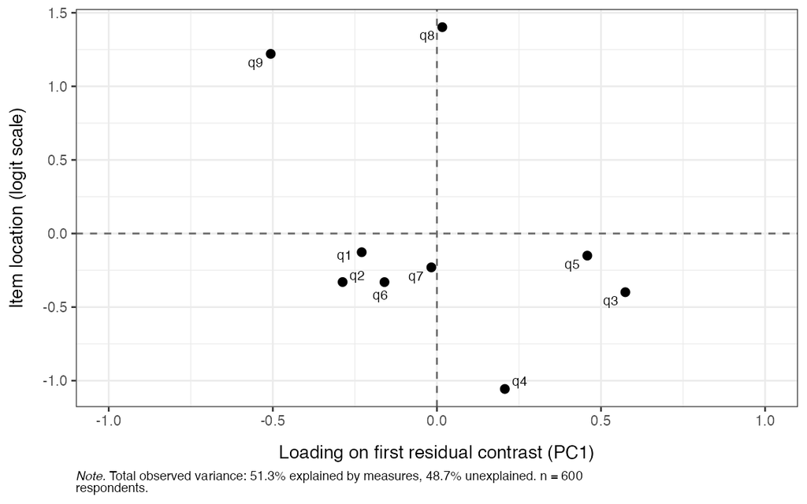

**Figure 4.** *Standardized loadings on the first residual contrast*

```r
RMdimResidualPCA(items, output = "ggplot")
```

### Martin-Löf test

This is a likelihood-ratio test of unidimensionality against an a priori specified multidimensional alternative. The *p*-value is obtained by parametric-bootstrap (Monte Carlo) sampling under the unidimensional null. A significant *p*-value constitutes strong evidence that items do not all measure one common latent variable. However, while a non-significant *p*-value indicates that data are consistent with one common latent variable across the partition, it is not to be considered proof of unidimensionality on its own.

In the use case demonstrated below, we have hypothesized that the five psychosomatic symptoms are a separate subscale from the other items. Looking at the PCA plot above, we can see tendencies of this clustering based on the loadings on the first residual contrast factor, with items 3-5 most clearly deviating from 1, 2, 6, and 9. Using the PCA plot to determine item partitioning for the M-L test is not recommended; see `?RMdimMartinLof` for details and references.

```r
mlof <- RMdimMartinLof(items, iterations = 100,
                       partition = list(
                         c("q1","q2","q6","q9"),
                         c("q3","q4","q5","q7","q8")
                       ),
                       seed = 4
)

mlof$p_value
```

```
#> [1] 0.00990099
```

```r
mlof$wle_correlation
```

```
#>   subscale_a subscale_b         r ci_lower  ci_upper      p_value   n
#> 1          1          2 0.7174163 0.676203 0.7541533 5.994126e-96 600
```

The *p*-value rejects unidimensionality across the partition, while the subscale WLE correlation indicates the dimensions are strongly related. Note that the Monte Carlo *p*-value’s resolution is limited by the number of iterations: the attainable values are $k/(B+1)$, so with $B = 100$ iterations the smallest possible *p*-value is $1/101 \approx 0.0099$ (returned as `mlof$p_value_floor`). A *p*-value *equal to* that floor means that no simulated statistic reached the observed one and should be read as $p < 0.01$ — the true *p*-value may be much smaller. Use more iterations (e.g. 1000, floor $\approx 0.001$) when reporting results. The M-L test results can be further investigated using the diagnostic function `RMdimMartinLofResiduals()`.

## 2. Local independence

Local independence (LD) can be assessed with multiple methods. Yen’s $Q_3$ statistic (Yen 1984) is the correlation between person-item standardized residuals for every item pair. There are two ways to evaluate LD with $Q_3$, both generated with a run of `RMlocdepQ3Cutoff()`. One is to determine a global simulation-based cutoff, where $Q_3$ values in the residual correlation matrix above the cutoff flag LD (Christensen et al. 2017).

```r
q3_cut <- RMlocdepQ3Cutoff(items, iterations = 100, parallel = FALSE,
                           seed = 4)
q3_results <- RMlocdepQ3(items, cutoff = q3_cut)
q3_results$matrix
```

Dynamic cut-off: 0.031 (mean Q3 -0.109 + 0.14). Global simulation cutoff (99th pctl of max-mean Q3) from 100 iterations. Correlations exceeding the cut-off may indicate local dependence; see the per-pair table for detail. n = 600 respondents.

|  | q1 | q2 | q3 | q4 | q5 | q6 | q7 | q8 | q9 | above_cutoff |
| --- | --- | --- | --- | --- | --- | --- | --- | --- | --- | --- |
| q1 |  |  |  |  |  |  |  |  |  |  |
| q2 | 0.23 |  |  |  |  |  |  |  |  | * |
| q3 | -0.19 | -0.19 |  |  |  |  |  |  |  |  |
| q4 | 0 | -0.03 | 0.08 |  |  |  |  |  |  | * |
| q5 | -0.2 | -0.25 | 0.09 | 0 |  |  |  |  |  | * |
| q6 | -0.18 | 0.02 | -0.15 | -0.14 | -0.12 |  |  |  |  |  |
| q7 | -0.13 | -0.18 | -0.2 | -0.08 | -0.13 | -0.05 |  |  |  |  |
| q8 | -0.17 | -0.3 | -0.18 | -0.16 | -0.1 | -0.18 | 0.08 |  |  | * |
| q9 | -0.12 | 0.06 | -0.23 | -0.31 | -0.24 | 0.02 | -0.19 | -0.11 |  | * |

For a more powerful $Q_3$ test, supply the same cutoffs object to `RMlocdepQ3()`. Each item pair is then judged against its own simulated null distribution and flagged on a multiplicity-corrected bootstrap *p*-value, which controls the family-wise error rate across all pairs (Johansson 2026). This is the default whenever the full cutoffs object is provided. The per-pair expected range is reported alongside as a reference, and it can be helpful to plot it against the observed value. We’ll limit the output to the 6 item-pairs that deviate the most.

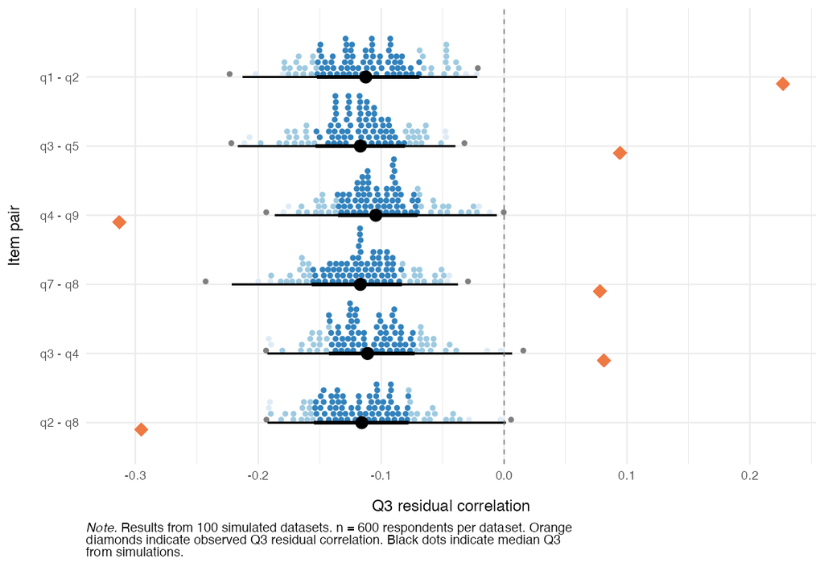

**Figure 5.** *Observed and expected $Q_3$ residuals*

```r
q3_plots <- RMlocdepQ3Plot(simfit = q3_cut, data = items, n_pairs = 6)
q3_plots$pairs
```

### Partial gamma LD

A second perspective on LD is the *partial gamma* coefficient (Kreiner and Christensen 2004; Kreiner 2007) between observed item pairs, conditional on the rest-score. Note that this function evaluates both directions of LD, thus the output is two tables. We’ll restrict the output to the 6 item-pairs with largest LD deviations.

```r
RMlocdepGamma(items, n_pairs = 6)
```

Partial gamma LD analysis. n = 600 respondents. Positive gamma indicates positive local dependence between items. Showing top 6 of 36 pairs by |gamma|. Direction 1: rest score = total - Item2.

| Item 1 | Item 2 | Partial gamma | Adj. p-value (BH) | p-value sign. | Gamma pair (max) |
| --- | --- | --- | --- | --- | --- |
| q1 | q2 | 0.531 | 0.000 | *** | 0.577 |
| q4 | q9 | -0.381 | 0.000 | *** | -0.381 |
| q2 | q9 | 0.332 | 0.000 | *** | 0.332 |
| q2 | q8 | -0.323 | 0.000 | *** | -0.323 |
| q7 | q8 | 0.303 | 0.000 | *** | 0.303 |
| q6 | q9 | 0.287 | 0.001 | *** | 0.287 |

Partial gamma LD analysis. n = 600 respondents. Positive gamma indicates positive local dependence between items. Showing top 6 of 36 pairs by |gamma|. Direction 2: rest score = total - Item2 (item pairs shown in the reverse order to direction 1).

| Item 1 | Item 2 | Partial gamma | Adj. p-value (BH) | p-value sign. | Gamma pair (max) |
| --- | --- | --- | --- | --- | --- |
| q2 | q1 | 0.577 | 0.000 | *** | 0.577 |
| q9 | q4 | -0.453 | 0.000 | *** | -0.381 |
| q8 | q2 | -0.415 | 0.000 | *** | -0.323 |
| q4 | q3 | 0.361 | 0.000 | *** | 0.361 |
| q5 | q3 | 0.303 | 0.000 | *** | 0.303 |
| q9 | q2 | 0.291 | 0.001 | *** | 0.332 |

You can also get simulation-based thresholds for partial gamma LD, using `RMlocdepGammaCutoff()`, which can be used with `RMlocdepGamma()` and also to plot the results with `RMlocdepGammaPlot()`. Supplying the cutoff object switches the table from the asymptotic *p*-values shown above to multiplicity-corrected bootstrap ones, and adds a `gamma_pair` column: each pair is tested once, on the larger of its two rest-score directions, so both tables carry the same result for a pair.

Item pairs flagged by both $Q_3$ and partial gamma are the strongest candidates for further inspection or possible item revision. Some argue for creating testlets by combining a locally dependent pair into a single polytomous super-item rather than eliminating one in an LD pair. I suggest looking closely at the item content before taking any action. Often, one will see very similarly worded items, where one item in an LD pair is clearly redundant. Another solution to LD can be the Graphical Loglinear Rasch Model by Kreiner and Christensen (Kreiner 2007), but that is beyond the scope of this vignette.

## 3. Ordered response category thresholds

For a polytomous item to function as intended, the thresholds separating adjacent response categories should be ordered: the threshold from “Not at all” to “Several days” should sit below the one from “Several days” to “More than half the days”, and so on.

A classical method to assess item response functions is to plot probability of response curves for each item and response category.

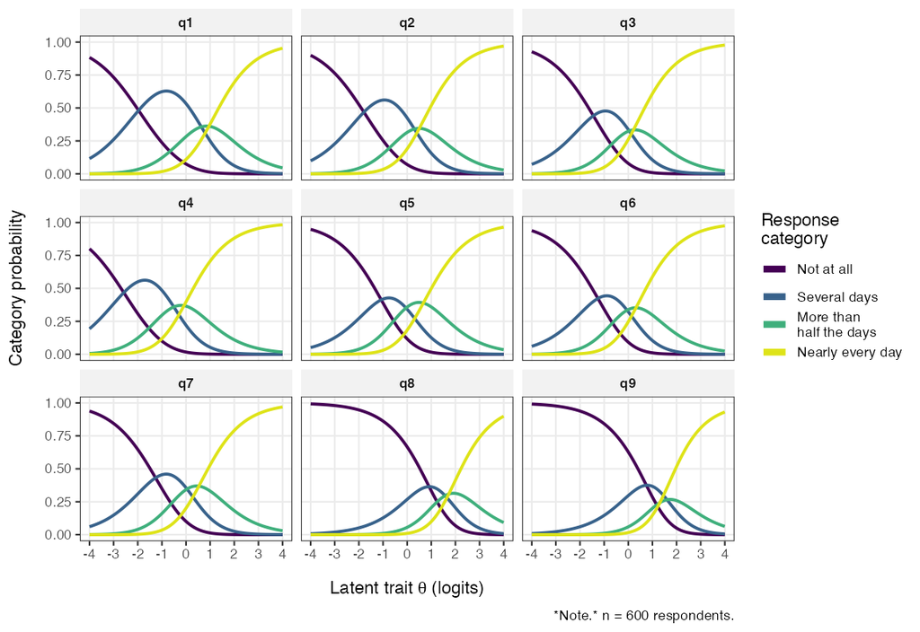

**Figure 6.** *Item Probability Function curves*

```r
RMitemCatProb(items, category_labels = item_resp)
```

In the plot above, each category curve should be the most likely response at some part of the latent continuum (x axis). Item category thresholds are the points where two adjacent category lines cross each other (where they are both equally probable). In the plot above, we can see that the second highest category does not work well compared to other categories. It is disordered for item 9 and, as is perhaps clearer in the plot below, shows very small distances from the adjacent categories in most items (see T2 and T3 below, which are the lower and upper thresholds for “More than half the days”).

`RMitemHierarchy()` plots each item’s threshold locations on the latent scale, ordered by overall item difficulty. Disordered thresholds appear as overlapping or reversed segments and are a clear signal that the response categories are not being used in the intended order.

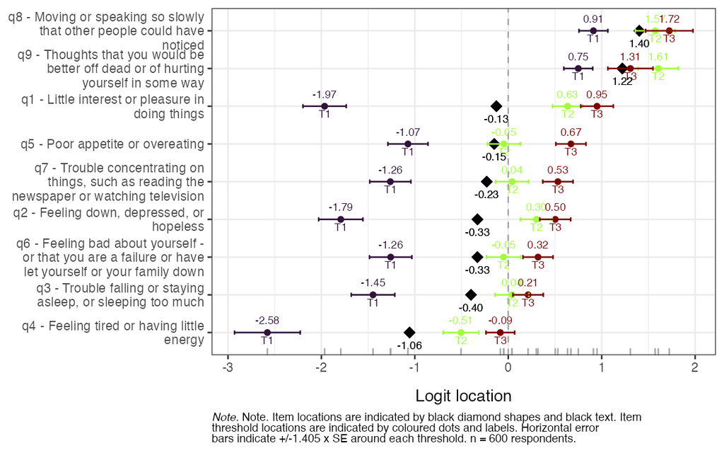

**Figure 7.** *Item-hierarchy*

```r
RMitemHierarchy(items, item_labels = item_desc)
```

The same disordering is visible in the bottom panel of the targeting plot further down, which marks never-modal categories and threshold reversals in red.

## 4. Invariance / no DIF

We use three complementary DIF assessments. The Andersen likelihood-ratio test (LRT, Andersen 1973) partitions the sample by an external variable, refits the model in each subgroup, and compares item locations. The partial gamma approach (Kreiner 2007; Christensen et al. 2021) looks for an association between item responses and the external variable *conditional on the rest-score*, and the Rasch tree (below) searches for DIF across covariates without pre-specified groups. All are run on the *gender* variable, which has some missing values that are automatically dropped by the functions (noted in a console message and/or table/figure caption output).

First, it is important to review the response distribution when dividing the sample. If there are zero or low (below 8 or so) responses in a category, there may be issues with estimating the model parameters.

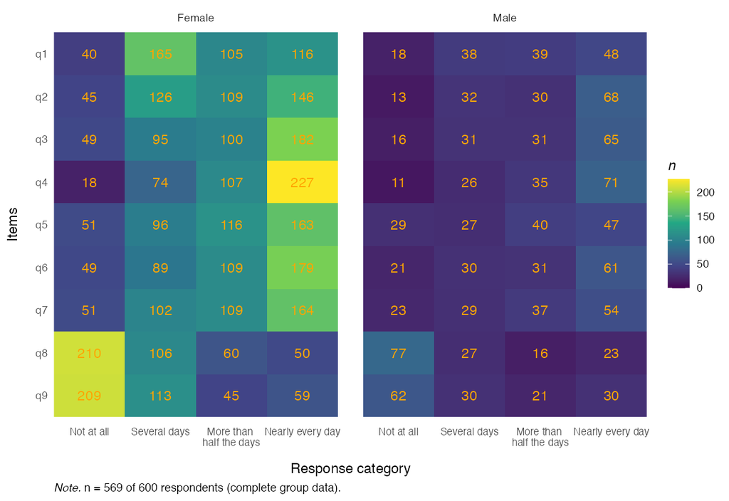

**Figure 8.** *DIF grouped response distribution tile plot*

```r
RMplotTile(items, category_labels = item_resp, group = phq9$gender)
```

### Andersen LR-test

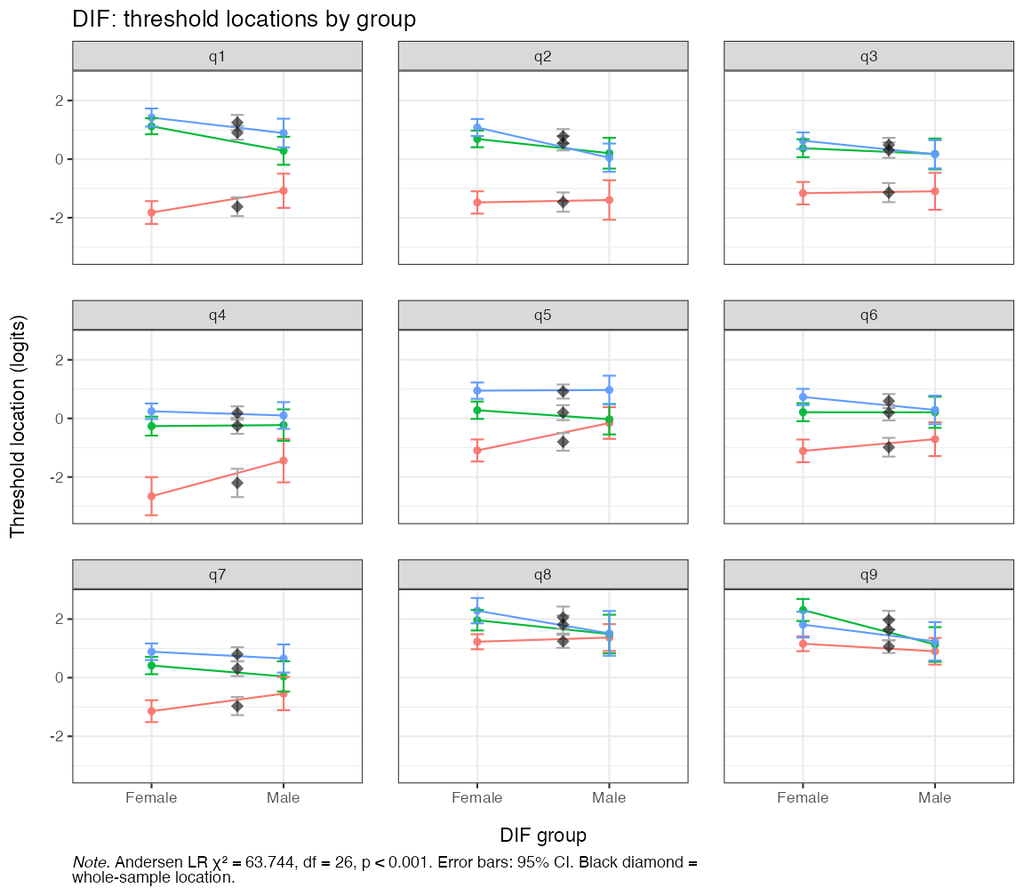

**Figure 9.** *Andersen LR-test DIF locations by gender*

```r
RMdifLR(items, dif_var = phq9$gender, level = "threshold", output = "ggplot")
```

The plot shows the item threshold locations estimated in each gender group with the corresponding confidence band. The global LR test is also reported in the plot caption, with a statistically significant test indicating problems with DIF between groups. However, this test is sensitive to sample size and number of items and should, like all global tests, be interpreted with care.

### Partial-gamma DIF

This plot annotates each item with its partial-$\gamma$ DIF coefficient and shows group differences within class intervals (respondents grouped by their total/latent score).

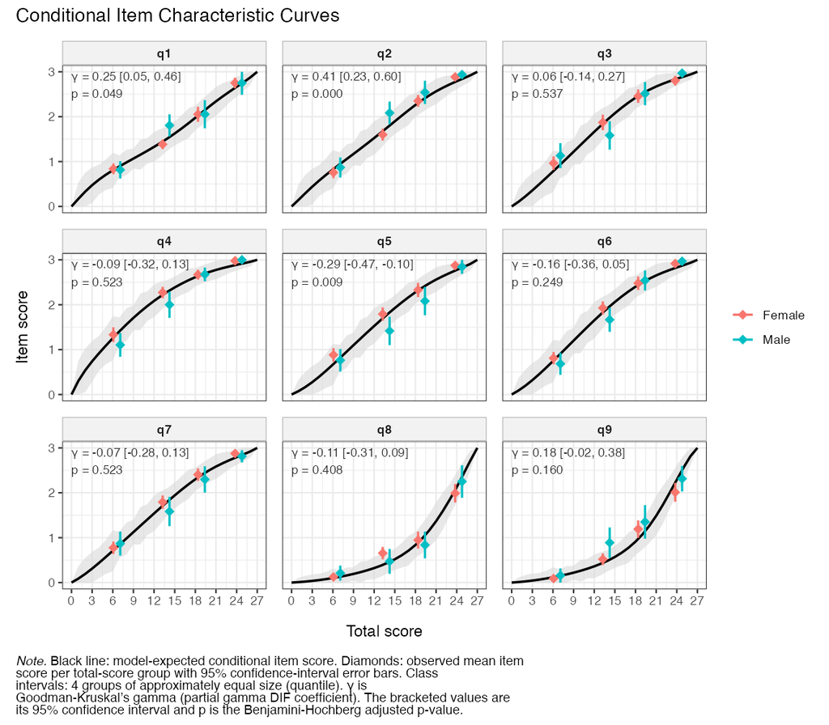

**Figure 10.** *Partial Gamma DIF Conditional Item Characteristic Curves*

```r
RMitemICCPlot(items, dif_var = phq9$gender, error_band = TRUE)
```

To demonstrate the FWER-adjusted *p*-values, we’ll run the partial-$\gamma$ DIF analysis with parametric bootstrap (only 100 here for rendering speed, which limits the reliability of the *p*-values).

```r
difpg <- RMdifGammaCutoff(items, dif_var = phq9$gender, iterations = 100,
                          parallel = FALSE, seed = 5)
RMdifGamma(items, cutoff = difpg, dif_var = phq9$gender, p_value = TRUE)
```

Partial gamma DIF analysis. n = 569 of 600 respondents (complete cases). Two-sided bootstrap p-values from 100 iterations (replacing the asymptotic BH p-values); multiplicity correction: Westfall-Young step-down (FWER); flagged at padj < 0.05. p-values cannot be smaller than 1/(100+1) = 0.0099. The interval is shown as description and is not the decision rule. Positive gamma indicates higher scores in higher DIF group levels. This is below the calibrated floor of 400, where the correction is mildly liberal and the family-wise error rate sits above the nominal level (Johansson, 2026).

| Item | Partial gamma | SE | Lower CI | Upper CI | Gamma low | Gamma high | p | p (adj) | Flagged |
| --- | --- | --- | --- | --- | --- | --- | --- | --- | --- |
| q1 | 0.251 | 0.104 | 0.046 | 0.456 | -0.126 | 0.173 | 0.0099 | 0.0396 | TRUE |
| q2 | 0.411 | 0.094 | 0.227 | 0.595 | -0.175 | 0.165 | 0.0099 | 0.0099 | TRUE |
| q3 | 0.064 | 0.103 | -0.138 | 0.266 | -0.167 | 0.187 | 0.5446 | 0.8713 | FALSE |
| q4 | -0.092 | 0.114 | -0.315 | 0.131 | -0.185 | 0.217 | 0.4059 | 0.8713 | FALSE |
| q5 | -0.286 | 0.092 | -0.467 | -0.104 | -0.148 | 0.171 | 0.0198 | 0.0297 | TRUE |
| q6 | -0.155 | 0.105 | -0.361 | 0.050 | -0.164 | 0.167 | 0.0891 | 0.3564 | FALSE |
| q7 | -0.075 | 0.102 | -0.275 | 0.126 | -0.164 | 0.164 | 0.4554 | 0.8713 | FALSE |
| q8 | -0.112 | 0.102 | -0.311 | 0.088 | -0.198 | 0.171 | 0.2772 | 0.6634 | FALSE |
| q9 | 0.180 | 0.100 | -0.015 | 0.376 | -0.237 | 0.181 | 0.0990 | 0.3960 | FALSE |

### Rasch tree (model-based recursive partitioning)

The DIF methods above compare groups that we specify in advance. The Rasch tree approach (Strobl et al. 2015) instead searches for DIF: the model is fitted to the full sample, covariates are tested for parameter instability, and whenever instability is detected the sample is split at the covariate value that maximizes it. The procedure then repeats within each subgroup, so several useful things come for free. Continuous covariates such as age need no arbitrary pre-categorization — the optimal cutpoint is estimated from the data. Interactions are handled naturally, since later splits are conditional on earlier ones (e.g. a gender split appearing only among older respondents). And if no instability is found, the tree simply does not split.

Statistically significant splits are not necessarily important splits, particularly in large samples. `RMdifTree()` therefore pairs the tree with an effect-size classification for every item at every split (Henninger et al. 2025): the Mantel-Haenszel odds ratio on the Delta scale developed at the Educational Testing Service (ETS) for dichotomous data, or the partial gamma coefficient for polytomous data, classified into the ETS categories A (negligible), B (slight to moderate), and C (moderate to large) (Holland and Thayer 1986; Zwick 2012). For partial gamma the B/C boundaries are the familiar 0.21 / 0.31 used by `RMdifGamma()`, so the two functions read on the same scale. Note that these boundaries are conventions carried over from large-scale educational testing, not values calibrated to your sample and items — in contrast to the simulation-based cutoffs used elsewhere in this package — so the A/B/C labels are best read as a rough magnitude guide rather than a calibrated test.

```r
RMdifTree(items, covariates = phq9$gender)
```

**Node 1 – gender: Female vs Male (n left = 426, n right = 143)**

Partial Credit Tree (9 items). n = 569 of 600 respondents (complete DIF covariates). Effect size: partial gamma (B/C thresholds = 0.21 / 0.31). alpha = 0.05. Flagged (Class B or C): 3 / 9 (item x split combinations). **Bold** rows are flagged.

| Item | EffectSize | SE | Class | Flagged |
| --- | --- | --- | --- | --- |
| **q1** | **0.251** | **0.104** | **B** | **yes** |
| **q2** | **0.411** | **0.094** | **C** | **yes** |
| q3 | 0.064 | 0.103 | A | no |
| q4 | -0.092 | 0.114 | A | no |
| **q5** | **-0.286** | **0.092** | **B** | **yes** |
| q6 | -0.155 | 0.105 | A | no |
| q7 | -0.075 | 0.102 | A | no |
| q8 | -0.112 | 0.102 | A | no |
| q9 | 0.180 | 0.100 | A | no |

The tree splits on gender, and the effect sizes match what the partial gamma analysis showed above: q2 is classified as C and q1 and q5 as B, while the remaining items are negligible (A). With a single binary covariate the tree reduces to the familiar two-group comparison — its advantages appear when you supply several covariates at once (`covariates = phq9[, c("gender", "age")]`), where it tests all of them, picks split points for continuous ones, and uncovers interactions.

Three options are worth knowing about: purification = “iterative” recomputes effect sizes while excluding already-flagged items from the matching score; stability = TRUE refits the tree on resamples to report how often each covariate is selected and where the cutpoints land — a guard against overinterpreting a single sample’s tree structure; and output = “plot” draws the tree with per-node item parameters.

## Next step

Since we found issues with item misfit, local dependence, and gender DIF, these need to be addressed before the scale is used for measurement. Notably, item 2 recurs across all three criteria — overfit, the strongest local dependence (with item 1), and the largest gender DIF — making it the natural first candidate for closer inspection. The recommended approach is iterative: remove a single item (for instance, an underfit item, or one item from an LD pair after reviewing item content), then re-run the full set of analyses, since fit indications for the remaining items change with every removal. Some of the flags above may be consequences of others: overfitting items can push fitting items into the underfit range, and underfitting items, especially from a second dimension, can make fitting items look overfit. When the sample is large enough, it is good practice to set aside a random holdout subsample before the analysis, so that the final item set can be confirmed in data that played no part in the item-reduction decisions.

The following sections are primarily of interest once an acceptable item set has been established; here we continue with all nine items for demonstration purposes.

## Targeting

A targeting plot is a Wright-map style display of how well the item thresholds match the distribution of person locations on the latent scale. The top panel is a histogram of person locations and the middle one a histogram of item threshold locations. The bottom panel draws each item as a bar partitioned into its response categories, with the threshold estimates and their confidence intervals below it. Each band spans the locations at which its category is the most likely response.

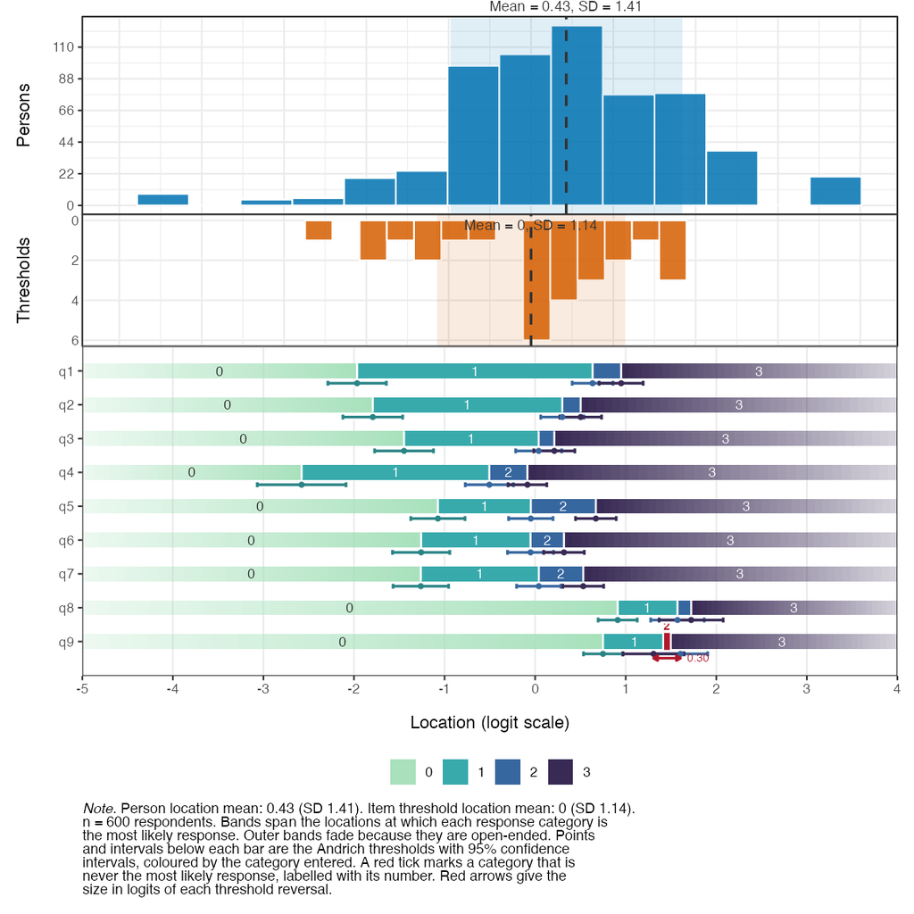

**Figure 11.** *Person-item targeting*

```r
RMtargeting(items)
```

That bottom panel doubles as a check on criterion 3 above. A category that is never the most likely response at any location collapses to a red tick labelled with its category number, and red arrows below the bar give the size of each threshold reversal in logits, so ordered thresholds leave no red marks at all. For the dot-and-whisker display of item thresholds used before version 1.3.0, pass `panel = "thresholds"`.

## Reliability

Reliability is reported two ways here: as summary coefficients for the scale as a whole, and as a curve showing how precision varies along the latent continuum.

### Summary coefficients

`RMreliability()` reports four metrics, in the order they appear in the output. Cronbach’s alpha, the person separation index (PSI), marginal reliability, and Relative Measurement Uncertainty (RMU), the last derived from posterior person-location uncertainty using plausible values. Marginal reliability is the latent-density-weighted mean of the conditional reliability curve shown below. Alpha, PSI and marginal can use a bootstrap for confidence intervals. All four range from 0 to 1, with higher values indicating better separation and precision.

```r
RMreliability(items, draws = 200, rmu_iter = 20, parallel = FALSE,
              seed = 6)
```

Reliability for 9 items, n = 600 respondents. PSI is the WLE-based separation reliability and excludes min/max scoring respondents. Marginal is the latent-density-weighted mean of the conditional reliability curve, sigma^2 / (sigma^2 + SEM(theta)^2).

| Metric | Estimate | Lower (95% HDCI) | Upper (95% HDCI) | Notes |
| --- | --- | --- | --- | --- |
| Cronbach’s alpha | 0.886 | NA | NA | no bootstrap |
| PSI | 0.838 | NA | NA | no bootstrap |
| Marginal (curve mean) | 0.876 | NA | NA | no bootstrap |
| RMU (WLE) | 0.881 | 0.867 | 0.895 | 200 PVs, 20 RMU iterations |

### Conditional reliability

A single coefficient implies that every respondent is measured with the same precision, which is rarely the case. Test information is highest where the item thresholds are concentrated and falls away towards the extremes, so the same scale can separate respondents well in the middle of its range and poorly at either end. `RMreliabilityCurve()` shows that directly.

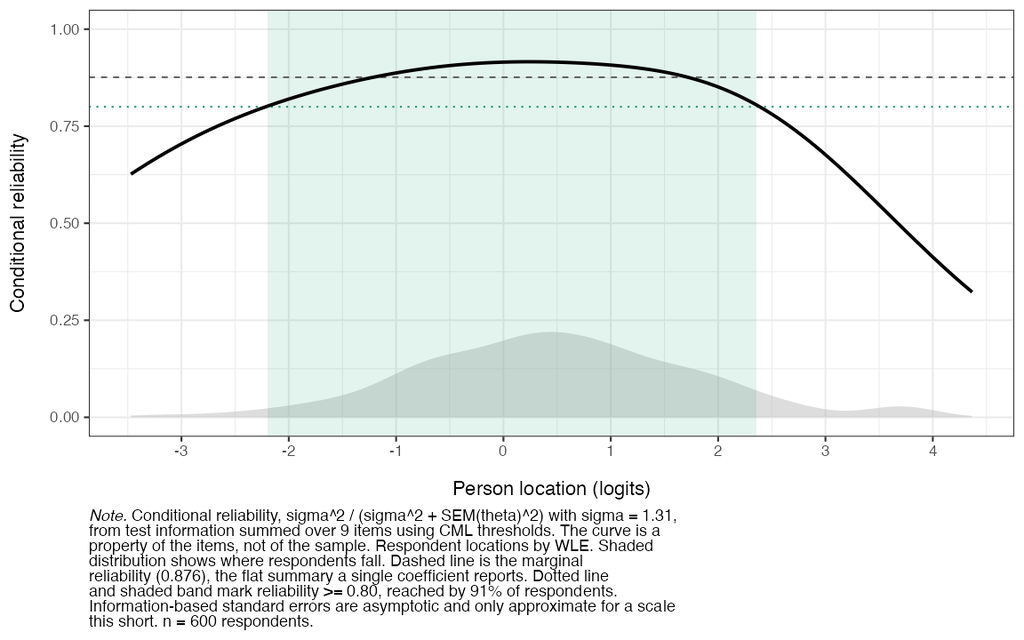

**Figure 12.** *Conditional reliability across the latent continuum*

```r
RMreliabilityCurve(items, statistic = "reliability", benchmark = 0.8)
```

The `benchmark` argument shades the region where the scale reaches a stated level and reports the share of respondents inside it, which is usually the practical question behind the figure. The dashed line is the marginal reliability from the table above, and the distribution behind the curve is the same set of person locations as the targeting plot. The default `statistic = "sem"` plots the conditional standard error in logits instead, which is the quantity to use when reporting the precision of an individual score. Test information is also available, using `statistic = "information"`.

## Item and person parameters

Item (threshold) locations can be easily summarized in wide or long format, with or without SEs.

```r
RMitemParameters(items, format = "wide")
```

Item thresholds via CML (Andrich thresholds, logit scale). SE shown. n = 600 respondents.

| item | t1 | t2 | t3 | location | se_t1 | se_t2 | se_t3 |
| --- | --- | --- | --- | --- | --- | --- | --- |
| q1 | -1.966 | 0.634 | 0.950 | -0.127 | 0.165 | 0.115 | 0.124 |
| q2 | -1.793 | 0.300 | 0.503 | -0.330 | 0.168 | 0.122 | 0.118 |
| q3 | -1.447 | 0.039 | 0.212 | -0.399 | 0.166 | 0.130 | 0.116 |
| q4 | -2.578 | -0.506 | -0.085 | -1.056 | 0.250 | 0.136 | 0.109 |
| q5 | -1.074 | -0.048 | 0.671 | -0.150 | 0.153 | 0.125 | 0.115 |
| q6 | -1.259 | -0.051 | 0.318 | -0.330 | 0.161 | 0.130 | 0.114 |
| q7 | -1.262 | 0.041 | 0.531 | -0.230 | 0.157 | 0.125 | 0.115 |
| q8 | 0.912 | 1.572 | 1.723 | 1.402 | 0.110 | 0.151 | 0.180 |
| q9 | 0.749 | 1.605 | 1.307 | 1.221 | 0.110 | 0.153 | 0.172 |

Person parameters are also sometimes referred to as thetas, latent scores, or person locations. By default, Warm’s weighted likelihood estimation (WLE) is used for minimal bias. The function exports one value and SE for each individual, below reduced to only print the first 10 rows of the dataframe. Note that all table outputs in `easyRasch2` can be output as dataframes instead, if so desired. The option `output = "file"` makes it easy to export estimated latent scores for each respondent to a CSV file.

```r
ppar <- RMpersonParameters(items, output = "dataframe")
head(ppar, 10)
```

```
#>         theta       sem sum_score n_answered extreme
#> 1   2.2760818 0.6184838        25          9   FALSE
#> 2  -0.9997531 0.4658741         7          9   FALSE
#> 3   1.1406643 0.4262412        20          9   FALSE
#> 4   0.3379335 0.3959994        15          9   FALSE
#> 5   3.6996335 1.3248428        27          9    TRUE
#> 6   1.1406643 0.4262412        20          9   FALSE
#> 7  -0.6129841 0.4288279         9          9   FALSE
#> 8   0.9701100 0.4155331        19          9   FALSE
#> 9   0.6465516 0.4019393        17          9   FALSE
#> 10 -3.2339486 0.9216600         1          9   FALSE
```

## Ordinal-to-interval transformation

For converting ordinal sum-scores to interval-scaled person-location estimates with associated standard errors, use `RMscoreSE()`.

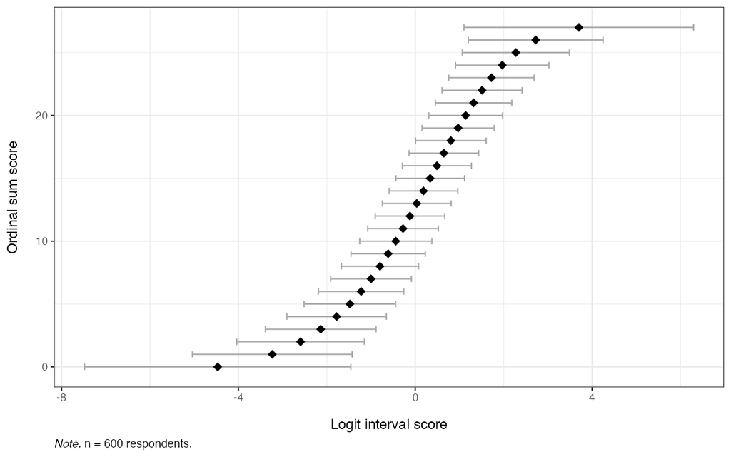

**Figure 13.** *Sum-score to WLE conversion with 95% CIs*

```r
RMscoreSE(items, output = "ggplot")
```

```r
RMscoreSE(items)
```

Person locations via Warm’s WLE (CML item parameters). n = 600 respondents.

| Ordinal sum score | Logit score | Logit std.error |
| --- | --- | --- |
| 0 | -4.469 | 1.536 |
| 1 | -3.234 | 0.922 |
| 2 | -2.594 | 0.737 |
| 3 | -2.138 | 0.638 |
| 4 | -1.779 | 0.574 |
| 5 | -1.480 | 0.528 |
| 6 | -1.224 | 0.493 |
| 7 | -1.000 | 0.466 |
| 8 | -0.798 | 0.445 |
| 9 | -0.613 | 0.429 |
| 10 | -0.440 | 0.417 |
| 11 | -0.277 | 0.408 |
| 12 | -0.119 | 0.401 |
| 13 | 0.034 | 0.397 |
| 14 | 0.186 | 0.396 |
| 15 | 0.338 | 0.396 |
| 16 | 0.491 | 0.398 |
| 17 | 0.647 | 0.402 |
| 18 | 0.806 | 0.408 |
| 19 | 0.970 | 0.416 |
| 20 | 1.141 | 0.426 |
| 21 | 1.320 | 0.441 |
| 22 | 1.512 | 0.462 |
| 23 | 1.723 | 0.492 |
| 24 | 1.968 | 0.539 |
| 25 | 2.276 | 0.618 |
| 26 | 2.724 | 0.778 |
| 27 | 3.700 | 1.325 |

`RMscoreSE()` also has an option for EAP scores (expected a posteriori).

## Person fit

Conditional person infit/outfit MSQ and the $\ell_z$ statistic are implemented, with Monte-Carlo resampling for *p*-values.

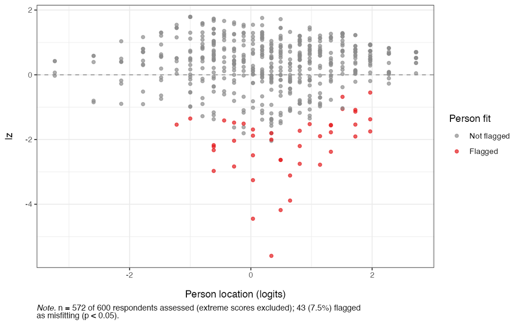

**Figure 14.** *Person fit with the lz statistic*

```r
pfit <- RMpersonFit(items, iterations = 100, output = "ggplot", seed = 7)
pfit$lz
```

## Where to next

- Each `RM*()` function is documented with its own `?function` reference page including a worked example.
- The simulation-based cutoffs used above (`RM*Cutoff()`) can be parallelised on multiple CPU cores via the `mirai` package; see the relevant help pages.
  - For a progress bar on time-consuming simulations, add `verbose = TRUE` to the function call. This should not be used when rendering Quarto/Rmd files.

## References

Andersen, Erling B. 1973. “A Goodness of Fit Test for the Rasch Model.” *Psychometrika* 38 (1): 123–40. https://doi.org/10.1007/BF02291180.

Chou, Yeh-Tai, and Wen-Chung Wang. 2010. “Checking Dimensionality in Item Response Models With Principal Component Analysis on Standardized Residuals.” *Educational and Psychological Measurement* 70 (5): 717–31. https://doi.org/10.1177/0013164410379322.

Christensen, Karl Bang, Jonathan D. Comins, Michael R. Krogsgaard, et al. 2021. “Psychometric Validation of PROM Instruments.” *Scandinavian Journal of Medicine & Science in Sports* 31 (6): 1225–38. https://doi.org/10.1111/sms.13908.

Christensen, Karl Bang, and Svend Kreiner. 2007. “A Monte Carlo Approach to Unidimensionality Testing in Polytomous Rasch Models.” *Applied Psychological Measurement* 31 (1): 20–30. https://doi.org/10.1177/0146621605286204.

Christensen, Karl Bang, Guido Makransky, and Mike Horton. 2017. “Critical Values for Yen’s Q3: Identification of Local Dependence in the Rasch Model Using Residual Correlations.” *Applied Psychological Measurement* 41 (3): 178–94. https://doi.org/10.1177/0146621616677520.

Henninger, Mirka, Jan Radek, Rudolf Debelak, and Carolin Strobl. 2025. “Partial Credit Trees Meet the Partial Gamma Coefficient for Quantifying DIF and DSF in Polytomous Items.” *Behaviormetrika* 52: 221–57. https://doi.org/10.1007/s41237-024-00252-3.

Holland, Paul W., and Dorothy T. Thayer. 1986. “Differential Item Functioning and the Mantel-Haenszel Procedure.” *ETS Research Report Series* 1986 (2): i–24. https://doi.org/10.1002/j.2330-8516.1986.tb00186.x.

Johansson, Magnus. 2025. “Detecting Item Misfit in Rasch Models.” *Educational Methods & Psychometrics* 3 (18). https://doi.org/10.61186/emp.2025.5.

Johansson, Magnus. 2026. “Simulation-Based Cutoffs for Conditional Item Fit in Rasch Models: Iterations, Multiplicity Correction, and Decision Stability.” *PsyArXiv*, ahead of print. https://doi.org/10.31234/osf.io/7pqz4_v2.

Kreiner, Svend. 2007. “Validity and Objectivity: Reflections on the Role and Nature of Rasch Models.” *Nordic Psychology* 59 (3): 268–98. https://doi.org/10.1027/1901-2276.59.3.268.

Kreiner, Svend. 2011. “A Note on Item–Restscore Association in Rasch Models.” *Applied Psychological Measurement* 35 (7): 557–61. https://doi.org/10.1177/0146621611410227.

Kreiner, Svend, and Karl Bang Christensen. 2004. “Analysis of Local Dependence and Multidimensionality in Graphical Loglinear Rasch Models.” *Communications in Statistics - Theory and Methods* 33 (6): 1239–76. https://doi.org/10.1081/STA-120030148.

Kroenke, Kurt, Robert L. Spitzer, and Janet B. W. Williams. 2001. “The PHQ-9: Validity of a Brief Depression Severity Measure.” *Journal of General Internal Medicine* 16 (9): 606–13. https://doi.org/10.1046/j.1525-1497.2001.016009606.x.

Müller, Marianne. 2020. “Item Fit Statistics for Rasch Analysis: Can We Trust Them?” *Journal of Statistical Distributions and Applications* 7 (1): 5. https://doi.org/10.1186/s40488-020-00108-7.

Strobl, Carolin, Julia Kopf, and Achim Zeileis. 2015. “Rasch Trees: A New Method for Detecting Differential Item Functioning in the Rasch Model.” *Psychometrika* 80 (2): 289–316. https://doi.org/10.1007/s11336-013-9388-3.

Yen, Wendy M. 1984. “Effects of Local Item Dependence on the Fit and Equating Performance of the Three-Parameter Logistic Model.” *Applied Psychological Measurement* 8 (2): 125–45. https://doi.org/10.1177/014662168400800201.

Zwick, Rebecca. 2012. “A Review of ETS Differential Item Functioning Assessment Procedures: Flagging Rules, Minimum Sample Size Requirements, and Criterion Refinement.” *ETS Research Report Series* 2012 (1): i–30. https://doi.org/10.1002/j.2333-8504.2012.tb02290.x.